# Bonus Round

Now let’s look at the bonus round data.

```r
#house keeping
rm(list=ls())

#load packages
packages <- c('broom', 'dplyr', 'modelr','jsonlite', 'effects', 'scales', 'xtable', 'shinystan', 'ggplot2', 'ggExtra', 'sjPlot', 'tidybayes', 'cowplot',  'brms','sjPlot', 'plyr', 'lme4',  'ggbeeswarm', 'gridExtra', 'reshape2', 'stargazer', 'coefplot', "grid", 'matrixcalc', 'parallel', 'ggsignif')
invisible(lapply(packages, require, character.only = TRUE))

source("../models.R")
#Participant data
source('../dataProcessing.R')
source('../statisticalTests.R')

bmtCol <- "#F0E442"
gpCol <- "#D55E00"

theme_set(theme_cowplot(font_size=12))
d <- dataImport('../experimentData/full.csv' ) #participant data


#load environments from json, unlist, transform into numeric, convert into matrix, and name dimensions
roughEnvironments <- lapply(fromJSON("../experiment/roughEnvironment.json"), FUN=function(x) matrix(as.numeric(unlist(x)), ncol=3, byrow=TRUE, dimnames=list(seq(1,64), c('x1', 'x2', 'y'))))
smoothEnvironments <- lapply(fromJSON("../experiment/smoothEnvironment.json"), FUN=function(x) matrix(as.numeric(unlist(x)), ncol=3, byrow=TRUE, dimnames=list(seq(1,64),  c('x1', 'x2', 'y'))))

#parameter estimates
bmtPars <-  read.csv('../rationalModels/parameters/BMT.csv')
gpPars <- read.csv('../rationalModels/parameters/gpucb.csv')


theme_set(theme_cowplot(font_size=12))

#Wrapper for brm models such that it saves the full model the first time it is run, otherwise it loads it from disk
run_model <- function(expr, modelName, path='../brmsModels', reuse = TRUE) {
  path <- paste0(path,'/', modelName, ".brm")
  if (reuse) {
    fit <- suppressWarnings(try(readRDS(path), silent = TRUE))
  }
  if (is(fit, "try-error")) {
    fit <- eval(expr)
    saveRDS(fit, file = path)
  }
  fit
}
```

# Bonus round data

```r
#Load data
dataFile <- "../experimentData/full.csv"
rawdata <- read.csv(dataFile, sep=",")
#remove empty rows#remove empty rows
rawdata <- rawdata[!grepl("NULL",rawdata$grid_assignmentID) & !grepl("NULL",rawdata$gabor_assignmentID),] #Todo: replace this with a more sophisticated way to check that both parts were completed
#extract sampleSize, records, and dat (deeply nested json data)
sampleSize <-nrow(rawdata)
all_opts = expand.grid(0:gridSize_0, 0:gridSize_0)
#build dataframe
bonusDF <- data.frame()

#Loop through data and build df
for (i in 1:sampleSize){
  dat <- rawdata[i,]
  subjd <- subset(d, id==dat$id & round == 10 & trial <=15)
  #GRID BONUS
  #judgments
  gridBonus <- fromJSON(as.character(dat$grid_experimentData))$bonusCollect
  gridJudgments <- data.frame(gridBonus$bonusStimuli)
  #Choice
  gridJudgments$chosen <- FALSE #Create new column
  gridChosen <- gridBonus$finalSelection
  gridJudgments[gridJudgments$x == gridChosen[1] & gridJudgments$y == gridChosen[2],]$chosen <- TRUE #assign chosen to final choice
  #Which environment?
  gridJudgments$BonusEnvironment <- fromJSON(as.character(dat$grid_experimentData))$envOrder[10]
  #Which rescaling factor?
  gridJudgments$RescaleFactor<-  fromJSON(as.character(dat$grid_experimentData))$scaleCollect[10]
  #Distance to the next closest option
  gridsubjd <- subset(subjd, context == 'Spatial')
  manhattanDistance <- sapply(gridJudgments$x, function(x) abs(gridsubjd$x - x)) + sapply(gridJudgments$y, function(y) abs(gridsubjd$y - y)) #calculate manhattan distance to all other observed options that round
  gridJudgments$minDistance <- apply(manhattanDistance, 2, min) #min distance to nearest
  #which context?
  gridJudgments$context <- "Spatial"


  #GABOR BONUS
  #judgments#judgments
  gaborBonus <- fromJSON(as.character(dat$gabor_experimentData))$bonusCollect
  gaborJudgments <- data.frame(gaborBonus$bonusStimuli)
  #Choice
  gaborJudgments$chosen <- FALSE #Create new column
  gaborChosen <- gaborBonus$finalSelection
  gaborJudgments[gaborJudgments$x == gaborChosen[1] & gaborJudgments$y == gaborChosen[2],]$chosen <- TRUE #assign chosen to final choice
  #Which environment?
  gaborJudgments$BonusEnvironment <- fromJSON(as.character(dat$gabor_experimentData))$envOrder[10]
  #Which rescaling factor?
  gaborJudgments$RescaleFactor<-  fromJSON(as.character(dat$gabor_experimentData))$scaleCollect[10]
  #Distance to the next closest option
  gaborsubjd <- subset(subjd, context == 'Conceptual')
  manhattanDistance <- sapply(gaborJudgments$x, function(x) abs(gaborsubjd$x - x)) + sapply(gaborJudgments$y, function(y) abs(gaborsubjd$y - y)) #calculate manhattan distance to all other observed options that round
  gaborJudgments$minDistance <- apply(manhattanDistance, 2, min) #min distance to nearest
  #which context?
  gaborJudgments$context <- "Conceptual"

  #general data
  dummy <- rbind(gridJudgments, gaborJudgments)
  dummy$id <- dat$id
  dummy$contextOrder <- dat$contextOrder
  dummy$environment <- ifelse(dat$environment==0, "Rough", "Smooth")

  #calculate true underlying value
  if (dummy$environment[1] == 'Rough'){
    gridenv <- roughEnvironments[[gridJudgments$BonusEnvironment[1]+1]] #convert to base 1 numbers
    gaborenv <- roughEnvironments[[gaborJudgments$BonusEnvironment[1]+1]]
  }else if (dummy$environment[1] == 'Smooth'){
    gridenv <- smoothEnvironments[[gridJudgments$BonusEnvironment[1]+1]]
    gaborenv <- smoothEnvironments[[gaborJudgments$BonusEnvironment[1]+1]]
  }
  #Convert 2D feature values to stimuli index
  gridBonusItems <- as.numeric(apply(subset(dummy, context=='Spatial')[,c('x', 'y')],MARGIN=1, FUN=function(row) which(row[1]==all_opts$Var1 & row[2]==all_opts$Var2)))
  gaborBonusItems <- as.numeric(apply(subset(dummy, context=='Conceptual')[,c('x', 'y')],MARGIN=1, FUN=function(row) which(row[1]==all_opts$Var1 & row[2]==all_opts$Var2)))
  #now extract the true underlying values and apply rescaling
  gridBonusTrueValues <- gridenv[gridBonusItems,'y'] * gridJudgments$RescaleFactor[1] + 5
  gaborBonusTrueValues <- gaborenv[gaborBonusItems,'y'] * gaborJudgments$RescaleFactor[1] + 5
  #Now put them in
  dummy$trueValue <- c(gridBonusTrueValues, gaborBonusTrueValues)
  #bind together
  bonusDF<-rbind(bonusDF, dummy)
}

#factors
bonusDF$environment <- factor(bonusDF$environment)
bonusDF$context <- factor(bonusDF$context)
bonusDF$judgmentError <- bonusDF$trueValue - bonusDF$givenValue
bonusDF$absolutejudgmentError <- abs(bonusDF$judgmentError)
#rescale given value back to range 0-100
bonusDF$meanEstimate <- bonusDF$givenValue/100 * bonusDF$RescaleFactor + 5

saveRDS(bonusDF, "../experimentData/bonusRound.Rds")
```

## Behavioral results

### How accurate were judgments relative to the ground truth?

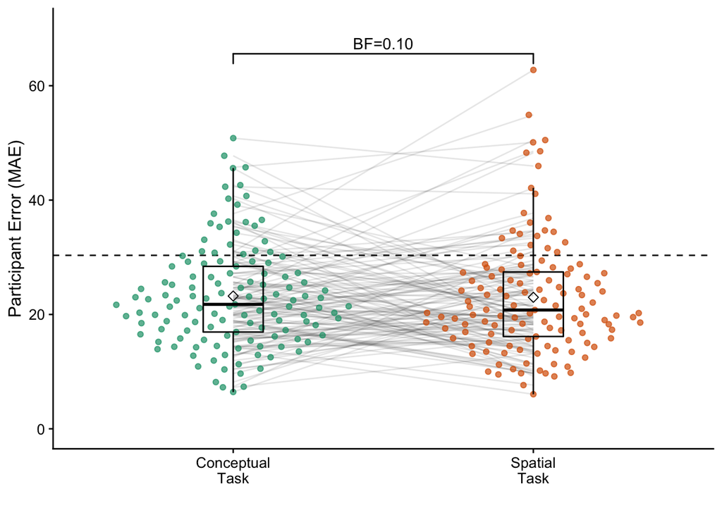

```r
#Prediction error compared to ground truth
indBonusDF <- ddply(bonusDF, ~id+context, plyr::summarize, MAE = mean(absolutejudgmentError))
randomError <- mean(abs(sample(bonusDF$trueValue, size = 10000, replace=T) - runif(10000,1,100))) #Simulate random error
contextLabels <- contextLabels <- c('Conceptual' = 'Conceptual Task', 'Spatial' = 'Spatial Task')

p1 <- ggplot(indBonusDF, aes(x = context, y = MAE, color = context))+
  geom_hline(yintercept = randomError, linetype = 'dashed')+
  geom_line(aes(group=id), color = 'black', alpha = 0.1)+
  geom_quasirandom(alpha = 0.7)+
  geom_boxplot(outlier.shape=NA, fill=NA, color = 'black', width = .2)+
  stat_summary(fun.y=mean, geom='point', color = 'black', shape = 5, size = 2)+
  scale_color_brewer(palette = 'Dark2')+
  xlab('')+
  coord_cartesian(ylim=c(0,70))+
  geom_signif(comparison=list(c('Conceptual', 'Spatial')), color = 'black', annotations = c('BF=0.10'))+
  ylab('Participant Error (MAE)')+
  scale_x_discrete(label=c('Conceptual\nTask', 'Spatial\nTask'))+
  theme(legend.position="none", strip.background=element_blank(), legend.key=element_rect(color=NA))
p1
```

In both tasks participants made equally accruate judgments (comparing mean absolute error: $t(128)=-0.2$, $p=.827$, $d=0.02$, $BF=.10$), which were far better than random chance (conceptual: $t(128)=-9.2$, $p<.001$, $d=0.8$, $BF>100$; spatial: $t(128)=-8.4$, $p<.001$, $d=0.7$, $BF>100$) and correlated between tasks ($r=.27$, $p=.002$, $BF=20$). Judgment errors were also correlated with bandit performance ($r=-.45$, $p<.001$, $BF>100$), such that participants who earned higher rewards in the bandit task had lower judgment errors on the bonus round.

```r
#Comparison to chance
ttestPretty(subset(indBonusDF, context=='Conceptual')$MAE, mu = randomError)
ttestPretty(subset(indBonusDF, context=='Spatial')$MAE, mu = randomError)

#Correlated error between tasks
corTestPretty(subset(indBonusDF, context=='Conceptual')$MAE, subset(indBonusDF, context=='Spatial')$MAE)

#Compare differences across tasks
ttestPretty(subset(indBonusDF, context == 'Spatial')$MAE, subset(indBonusDF, context == 'Conceptual')$MAE, paired=T)

#correlating bandit performance with judgment performance
corTestPretty(ddply(bonusDF, ~id, plyr::summarize, MAE = mean(absolutejudgmentError))$MAE, ddply(d, ~id, plyr::summarize, avgReward = mean(z))$avgReward)
```

And while judgment errors were unaffected by the distance of the target stimuli to the nearest observed reward in the conceptual task ($r=.02$, $p=.442$, $BF=.09$), we do find a slight relationship in the spatial task ($r=.09$, $p<.001$, $BF=20$), where closer targets had lower judgment errors.

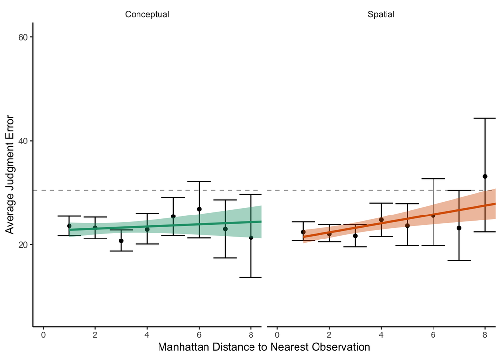

```r
#corTestPretty(subset(bonusDF, context == 'Conceptual')$minDistance, subset(bonusDF, context == 'Conceptual')$absolutejudgmentError)
#corTestPretty(subset(bonusDF, context == 'Spatial')$minDistance, subset(bonusDF, context == 'Spatial')$absolutejudgmentError)

upperlimit <- quantile(bonusDF$minDistance, .75) + 1.5 * IQR(bonusDF$minDistance) #upper limit for distance based on Tukey outlier criterion, so we don't start seeing trends at extreme distances that are not representative of the marginal distribution
ggplot(bonusDF, aes(x = minDistance, y = absolutejudgmentError, color = context, fill = context))+
  geom_hline(yintercept = randomError, linetype = 'dashed')+
  stat_summary(fun.y = mean, geom='point', color = 'black')+
  stat_summary(fun.data = mean_cl_boot, geom='errorbar', color = 'black')+
  geom_smooth(method='lm')+
  theme_classic()+
  coord_cartesian(xlim = c(0,round(upperlimit)))+
  scale_color_brewer(palette = 'Dark2')+
  scale_fill_brewer(palette = 'Dark2')+
  xlab('Manhattan Distance to Nearest Observation')+
  ylab('Average Judgment Error')+
  facet_grid(~context)+
  theme(legend.position="none", strip.background=element_blank(), legend.key=element_rect(color=NA))
```

### Confidence judgments

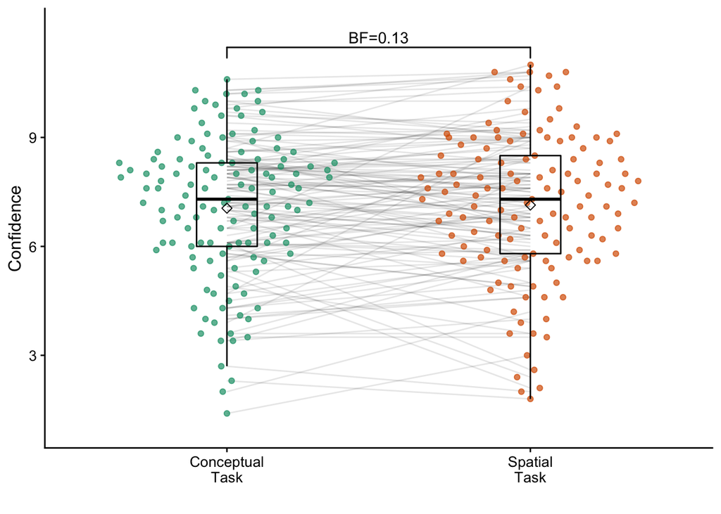

```r
#Compare overall confidence
indConfDF <- ddply(bonusDF, ~id+context, plyr::summarize, conf = mean(howCertain))
p2 <- ggplot(indConfDF, aes(x=context, y = conf,  color = context))+
  geom_line(aes(group=id), color = 'black', alpha = 0.1)+
  geom_quasirandom(alpha = 0.7)+
  geom_boxplot(fill='NA', color='black', width = .2, outlier.shape=NA) +
  #geom_dotplot(binaxis='y', stackdir='center', shape=16, color='black', alpha = 0.5, dotsize = 1.5 )+
  stat_summary(fun.y=mean, geom='point', color = 'black', shape = 5, size = 2)+
  #geom_line(aes(group=participant), color = 'black', alpha = 0.2)+
  scale_color_brewer(palette='Dark2')+
  ylab('Confidence')+
  xlab('')+
  scale_y_continuous(limits = c(1,12), breaks=c(3,6,9))+
  geom_signif(comparison=list(c('Conceptual', 'Spatial')), color = 'black', annotations = c('BF=0.13'))+
  scale_x_discrete(label=c('Conceptual\nTask', 'Spatial\nTask'))+
  theme(legend.position="top")+
  theme(legend.position="none", strip.background=element_blank(), legend.key=element_rect(color=NA))
p2
```

Participants were equally confident in both domains ($t(128)=-0.8$, $p=.452$, $d=0.04$, $BF=.13$), with correlated levels of confidence across tasks ($r=.79$, $p<.001$, $BF>100$) suggesting some participants were consistently more confident than others. There also appears to be somewhat of a Dunning-Krueger effect, where more confident people also had larger judgment errors ($r=.31$, $p<.001$, $BF=91$) and performed worse on the bandit task ($r=-.28$, $p=.001$, $BF=28$).

```r
#Compare confidence judgments between tasks
ttestPretty(subset(indConfDF, context=='Conceptual')$conf, subset(indConfDF, context=='Spatial')$conf, paired=T)
#correlation
corTestPretty(subset(indConfDF, context=='Conceptual')$conf, subset(indConfDF, context=='Spatial')$conf)

#Correlation to judgment accuracy
corTestPretty(ddply(bonusDF, ~id, plyr::summarize, conf = mean(howCertain))$conf,ddply(bonusDF, ~id, plyr::summarize, MAE = mean(absolutejudgmentError))$MAE)

#Correlation to bandit performance
corTestPretty(ddply(bonusDF, ~id, plyr::summarize, conf = mean(howCertain))$conf, ddply(d, ~id, plyr::summarize, avgReward = mean(z))$avgReward)
```

Confidence judgments were not substantially affected by the minimum distance to the nearest observed reward (conceptual: $r=-.06$, $p=.038$, $BF=.56$; spatial: $r=-.01$, $p=.676$, $BF=.07$).

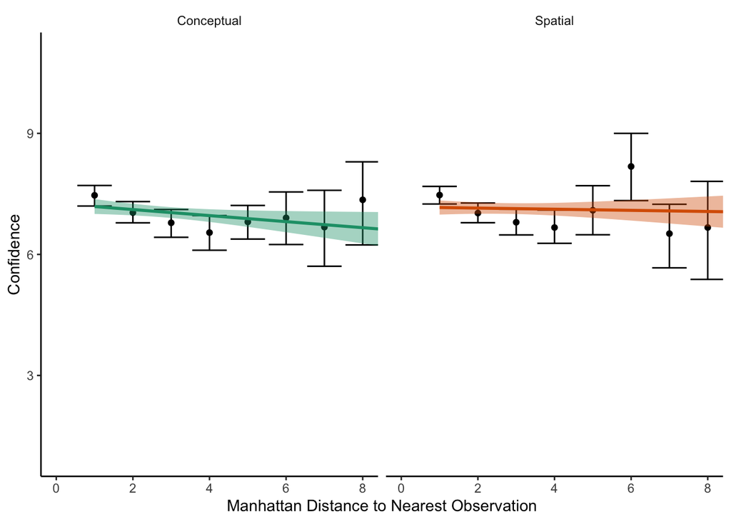

```r
#corTestPretty(subset(bonusDF, context == 'Conceptual')$minDistance, subset(bonusDF, context == 'Conceptual')$howCertain)
#corTestPretty(subset(bonusDF, context == 'Spatial')$minDistance, subset(bonusDF, context == 'Spatial')$howCertain)

ggplot(bonusDF, aes(x = minDistance, y = howCertain, color = context, fill = context))+
  stat_summary(fun.y = mean, geom='point', color = 'black')+
  stat_summary(fun.data = mean_cl_boot, geom='errorbar', color = 'black')+
  geom_smooth(method='lm')+
  theme_classic()+
  coord_cartesian(xlim = c(0,round(upperlimit)))+
  scale_color_brewer(palette = 'Dark2')+
  scale_fill_brewer(palette = 'Dark2')+
  xlab('Manhattan Distance to Nearest Observation')+
  ylab('Confidence')+
  facet_grid(~context)+
  theme(legend.position="none", strip.background=element_blank(), legend.key=element_rect(color=NA))
```

We get an affect where the highest confidence corresponds to the largest judgment errors

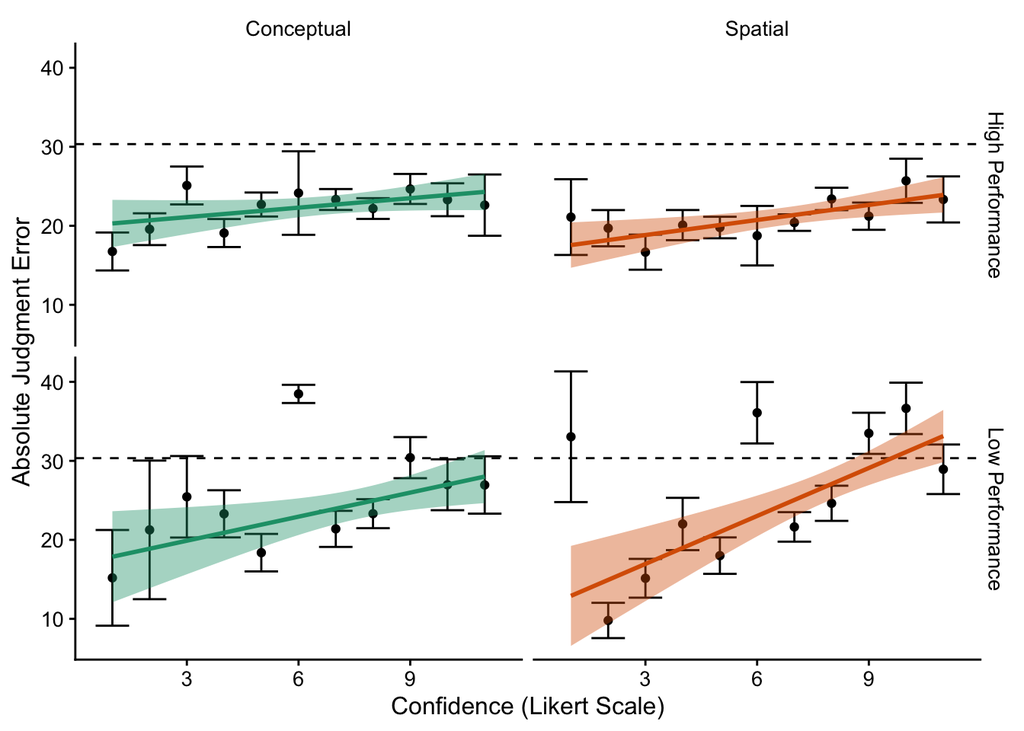

```r
#Median split by bandit task performance
medianBonus <- median(d$bonus)
topPerformers <- unique(d[d$bonus>medianBonus,]$id)
bonusDF$performance <- 'Low Performance'
bonusDF[bonusDF$id %in% topPerformers,]$performance <- 'High Performance'

ggplot(bonusDF, aes(x = howCertain, y = absolutejudgmentError, color = context, fill = context))+
  geom_hline(yintercept = randomError, linetype = 'dashed')+
  stat_summary(fun.y = mean, geom='point', color = 'black')+
  stat_summary(fun.data = mean_se, geom='errorbar', color = 'black')+
  geom_smooth(method='lm')+
  facet_grid(performance~context)+
  scale_color_brewer(palette = 'Dark2')+
  scale_fill_brewer(palette = 'Dark2')+
  xlab('Confidence (Likert Scale)')+
  ylab('Absolute Judgment Error')+
  theme(legend.position="none", strip.background=element_blank(), legend.key=element_rect(color=NA))
```

This also holds when we run a mixed effects model, controlling for individual variability using participant id as a random intercept ($b_{conf}=.50$; 95% HPD: $[0.02,1.01]$)

```r
#Mixed effects models
prior <- c(set_prior("normal(0,1)", class = "b"),set_prior("normal(0,1)", class = "sd"))
confJudgments <- run_model(brm(absolutejudgmentError ~ 0+intercept + howCertain*context +(1+howCertain*context|id), family = student, data=bonusDF, cores=4,  control = list(adapt_delta = 0.99)), modelName = 'confJudgments')
fixedTerms <- fixef(confJudgments)#Look at fixed terms
fixedTerms
```

```
##                             Estimate Est.Error        Q2.5     Q97.5
## intercept                 19.2441385 1.6856964 15.81429996 22.535083
## howCertain                 0.5037102 0.2506895  0.01658593  1.012909
## contextSpatial            -3.3080302 2.4549972 -8.05984551  1.552963
## howCertain:contextSpatial  0.3709868 0.3504528 -0.33264618  1.058452
```

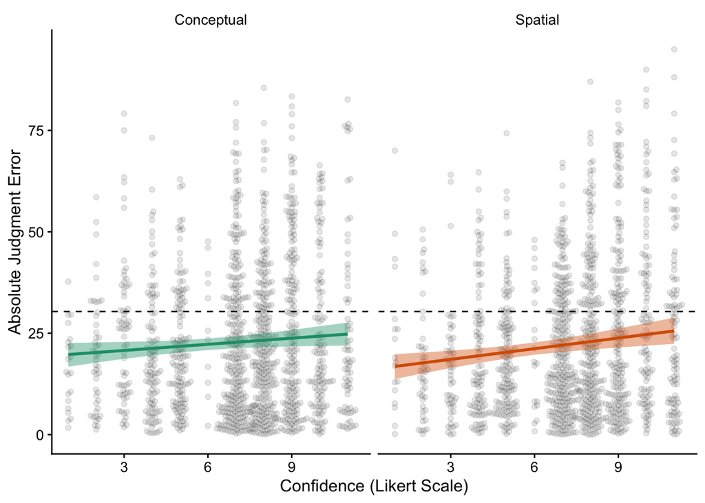

```r
#bayes_R2(confJudgments) #R2

#Now generate predictions, removing id as a random effect
xseq <- seq(1,11)
newdat <-data.frame(context = rep(c("Conceptual","Spatial"), each=11), howCertain = rep(xseq,2))
preds <- fitted(confJudgments, re_formula = NA, newdata = newdat, probs = c(0.025, 0.975))
#create new fixed effects dataframe
fixedDF <- data.frame( context = rep(c("Conceptual","Spatial"), each=11), howCertain = rep(xseq,2),
                                   absolutejudgmentError = preds[,1], lower = preds[,3], upper = preds[,4] )



ggplot(bonusDF, aes(x = howCertain, y = absolutejudgmentError, color = context, fill = context))+
  geom_hline(yintercept = randomError, linetype = 'dashed')+
  geom_beeswarm(alpha = 0.1, color = 'black')+
  geom_line(data = fixedDF,  size = 1)+ #GP is
  geom_ribbon(data = fixedDF, aes(ymin=lower, ymax = upper), color = NA, alpha = 0.4 )+
  #stat_summary(fun.y = mean, geom='point', color = 'black')+
  #stat_summary(fun.data = mean_se, geom='errorbar', color = 'black')+
  #geom_smooth(method='lm')+
  facet_grid(~context)+
  scale_color_brewer(palette = 'Dark2')+
  scale_fill_brewer(palette = 'Dark2')+
  xlab('Confidence (Likert Scale)')+
  ylab('Absolute Judgment Error')+
  theme(legend.position="none", strip.background=element_blank(), legend.key=element_rect(color=NA))
```

# Model predictions

Now using models with parameters estimated from the bandit tasks in rounds one to nine, we can perform out-of-task predictions for participant judgments about expected reward and confidence.

```r
#placeholders for model predictions
bonusDF$GPmean<-NA
bonusDF$GPuncertainty <- NA
bonusDF$BMTmean<-NA
bonusDF$BMTuncertainty<-NA


bonusRoundResults <- data.frame()
#loop through subjects
for (model in c("BMT", "GP")){
  for (i in unique(d$id)){
    #loop through context
    for (contextType in c("Spatial", "Conceptual")){
      observations <- subset(d, id==i & context == contextType & round==10 & trial<=15 ) #observation data
      judgments <- subset(bonusDF, id == i & context == contextType) #judgments

      #parameters
      if (model=="BMT"){
        parameters <- bmtPars
      }else if (model=='GP'){ #GP parameters depend on context
        parameters <- gpPars
      }
      params <- subset(parameters, participant == i & context == contextType) #parameter estimates

      #Load environment
      envNum <- unique(judgments$BonusEnvironment) + 1 #convert to base_0 from base_1
      environmentType <- unique(judgments$environment)
      if (environmentType == "Smooth"){
        bonusEnv <- data.frame(smoothEnvironments[[envNum]])
      }else {
        bonusEnv <- data.frame(roughEnvironments[[envNum]])
      }

      #Compute model predictions
      X <- as.matrix(observations[,c('x','y')]) #construct set of observations
      Y <- observations$z

      #Model Predictions
      if (model=="BMT"){ #BMT
        #parameters
        kError <- median(params$kError)
        beta <- median(params$beta)
        tau <- median(params$tau)

        #learning phase
        prevPost <- NULL
        for (t in 1:15){
          modelPredictions <- bayesianMeanTracker(x = X[t,], y = Y[t], prevPost = prevPost, theta = c(kError))
          prevPost <- modelPredictions
        }

      } else if (model=='GP'){ #GP
        #parameters
        lambda <- median(params$lambda)
        beta <- median(params$beta)
        tau <- median(params$tau)

        #Run GP
        modelPredictions <- gpr(X.test = as.matrix(all_opts), theta = c(lambda, lambda, 1, .0001), X=X, Y=Y, k=rbf)
      } else if (model=='SimKernel'){ #SimKernel
        #parameters
        lambda <- median(params$lambda)
        beta <- median(params$beta)
        tau <- median(params$tau)
        p <- median(params$p)

        #Run GP
        modelPredictions <- gpr(X.test = as.matrix(all_opts), theta = c(lambda, lambda, 1, .0001,p), X=X, Y=Y, k=shepardKernel)
      }

      #Compare predictions to judgment
      #mean judgment error in RMSE and MAE
      location_index <- apply(as.matrix(judgments[,c('x','y')]),MARGIN=1, FUN=function(row) which(row[1]==all_opts$Var1 & row[2]==all_opts$Var2))
      model_means <- (modelPredictions[location_index,]$mu + .5) * 100 #Rescale to range 0-100
      rmse <- sqrt(mean((judgments$meanEstimate - model_means)^2))
      mae <- mean(abs(judgments$meanEstimate - model_means))
      #Add model means to bonusDF
      if (model=="BMT"){
        bonusDF[bonusDF$id==i & bonusDF$context == contextType,]$BMTmean <- model_means
      }else if (model=='GP'){
        bonusDF[bonusDF$id==i & bonusDF$context == contextType,]$GPmean <- model_means
      }

      #Uncertainty
      model_uncertainty <- modelPredictions[location_index,]$sig
      #correlation <- cor.test(1/judgments$howCertain, model_uncertainty, method = "spearman")$estimate[[1]]
      if (model=="BMT"){
        bonusDF[bonusDF$id==i & bonusDF$context == contextType,]$BMTuncertainty <- model_uncertainty
      }else if (model=='GP'){
        bonusDF[bonusDF$id==i & bonusDF$context == contextType,]$GPuncertainty<- model_uncertainty
      }
      #choice prediction
      utilities <- modelPredictions[location_index,]$mu + (beta*sqrt(model_uncertainty))
      utilities <- utilities - max(utilities) #prevent overflow
      choiceProb <- exp(utilities/tau)
      choiceProb <- choiceProb/sum(choiceProb)
      nLL <- -log(choiceProb[judgments$chosen])
      #TODO add choice probability
      #put it together
      dummy <- data.frame(participant = i, context = contextType, environment = environmentType, modelName = model, MAE= mae,RMSE=rmse, nLL = nLL)
      bonusRoundResults <- rbind(bonusRoundResults, dummy)
    }
  }
}


bonusRoundResults$modelName <- factor(bonusRoundResults$modelName, levels = c("GP", "BMT"))
meanDF <- ddply(d, .(id, context, environment, contextOrder), plyr::summarize, meanScore = mean(z)) #compute mean scores
bonusRoundResults <- merge(bonusRoundResults, meanDF, by.x=c("participant","context", "environment"), by.y=c("id", "context", "environment"))
bonusRoundResults$contextOrder <- factor(bonusRoundResults$contextOrder)
levels(bonusRoundResults$contextOrder)<- c("Spatial First", "Conceptual First")

saveRDS(bonusRoundResults, "../modelResults/bonusRoundResults.Rds")
```

## Model comparison

Let’s do a mixed effects regression, where we model `modelPrediction ~ humanPrediction + context + humanPrediction*context + (1 + humanPrediction | id)`. This model has an intercept term, a coefficient for the human predictions, a coefficient for context (with dummy coding for spatial = 1 and conceptual = 0), and the interaction between human predictions and the spatial context. In addition, this model has random intercepts for each participant and a random slope relative to the human prediction values. We then plot the posterior fixed effect as an estimate of how well the participant predictions match the model predictions, when we account for individual differences.

Note that this analysis is ommitted for the BMT, because since it invariably makes the same prediction for each unobserved option, this corresponds to a model with a slope of 0.

```r
#Normalization function to range 0-1 for use with GP uncertainty estimates (since the units are not so interpretable)
predictionDF <- data.frame(id= rep(bonusDF$id, 2), humanPrediction = rep(bonusDF$meanEstimate, 2),
                           humanConfidence = rep(bonusDF$howCertain, 2), context = rep(bonusDF$context, 2),
                           environment = rep(bonusDF$environment, 2), modelPrediction = c(bonusDF$GPmean, bonusDF$BMTmean),
                           modelUncertainty = c(bonusDF$GPuncertainty, bonusDF$BMTuncertainty),
                           model = rep(c('GP', 'BMT'),each = nrow(bonusDF) ))


predictionDF$model <- factor(predictionDF$model, level <- c('GP', 'BMT'))


#Mixed effects models
prior <- c(set_prior("normal(0,1)", class = "b"),set_prior("normal(0,1)", class = "sd"))
GPjudgments <- run_model(brm(modelPrediction ~ 0+ intercept+ humanPrediction+context+humanPrediction*context +(1+humanPrediction*context|id), data=subset(predictionDF, model=='GP'),
                             prior = prior, cores=4,  iter = 4000, warmup = 1000,  control = list(adapt_delta = 0.99)), modelName = 'GPbonusJudgments')

bayes_R2(GPjudgments) #R2
```

```
##     Estimate Est.Error      Q2.5     Q97.5
## R2 0.4369129 0.0112053 0.4144671 0.4581812
```

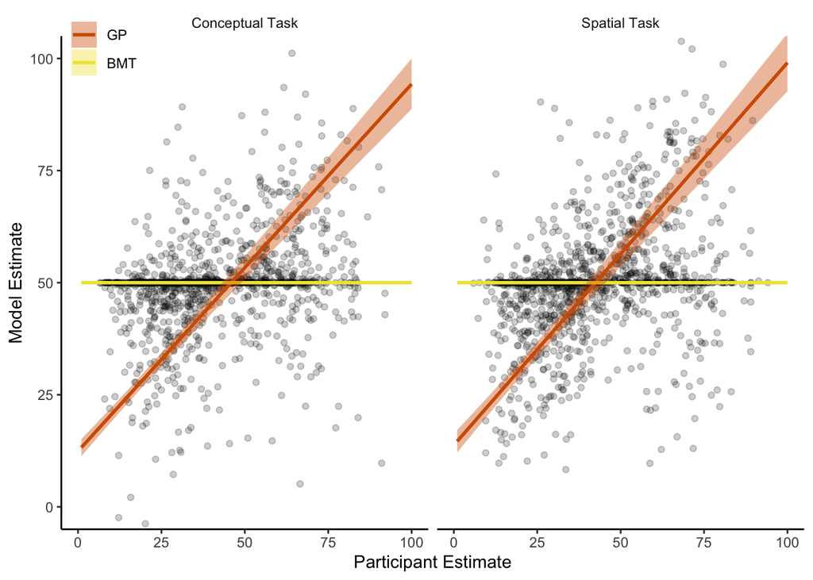

```r
fixedTerms <- fixef(GPjudgments)#Look at fixed termsz

#Now generate predictions, removing id as a random effect
xseq <- seq(1,100)
newdat <-data.frame(context = rep(c("Conceptual","Spatial"), each=100), humanPrediction = rep(xseq,2))
preds <- fitted(GPjudgments, re_formula = NA, newdata = newdat, probs = c(0.025, 0.975))
#create new fixed effects dataframe
fixedDF <- data.frame(model='GP', context = rep(c("Conceptual","Spatial"), each=100), humanPrediction = rep(xseq,2),
                                   modelPrediction = preds[,1], lower = preds[,3], upper = preds[,4] )
#create BMT df giving the same prediction for all options
bmtDF <- data.frame(model='BMT', context = rep(c("Conceptual","Spatial"), each=100), humanPrediction = rep(xseq,2), modelPrediction = 50, lower = NA, upper = NA)
fixedDF <- rbind(fixedDF, bmtDF)


p4 <- ggplot(subset(predictionDF, model=='GP'), aes(humanPrediction, modelPrediction, color = model, fill  = model)) +
  geom_point(alpha =.2, color = 'black', fill=NA) +
  #geom_hline(yintercept = 50, size = 1, color = bmtCol)+ #BMT is a flat line
  geom_line(data = fixedDF,  size = 1)+ #GP is
  geom_ribbon(data = fixedDF, aes(ymin=lower, ymax = upper), color = NA, alpha = 0.4 )+
  #geom_abline(slope = 1, linetype = 'dashed')+
  coord_cartesian(xlim = c(0,100), ylim=c(0,100))+
  theme_classic()+
  scale_fill_manual(values = c(gpCol,bmtCol), name='')+
  scale_color_manual(values = c(gpCol,bmtCol), name='')+
  facet_grid(~context, labeller = as_labeller(contextLabels) )+
  xlab("Participant Estimate")+
  ylab("Model Estimate")+
  theme(legend.position=c(0, 1.1), legend.justification=c(0,1), strip.background=element_blank(), legend.key=element_blank(), legend.background=element_blank())
p4
```

We can also do a similar analysis for the relationshop between the model uncertainty predictions and confidence judgments with the formula `modelUncertainty ~ humanConfidence+context + humanConfidence *context + (1 + humanConfidence | id)`

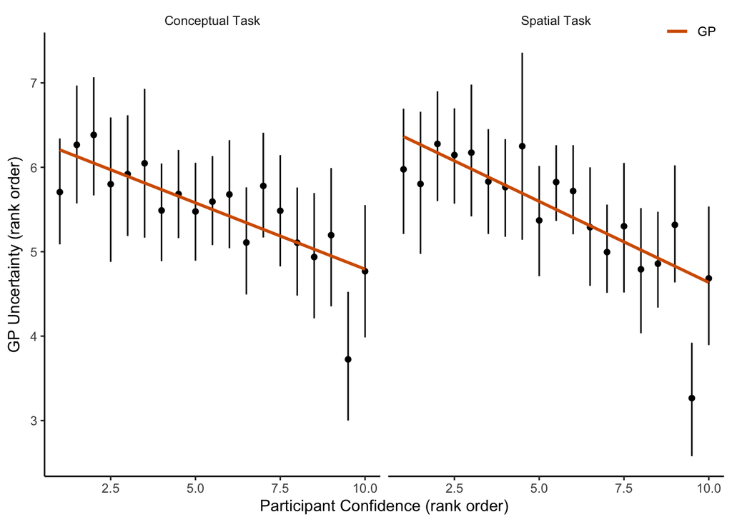

```r
#Model uncertainty to participant confidence
prior <- c(set_prior("normal(0,1)", class = "b"),set_prior("normal(0,1)", class = "sd"))
GPconf <- run_model(brm(modelUncertainty~  0 + intercept + humanConfidence*context +(1+humanConfidence*context|id), data=subset(predictionDF, model=='GP'),
                        prior = prior, cores=4,  iter = 4000, warmup = 1000,  control = list(adapt_delta = 0.99)), modelName = 'GPbonusconf')
#bayes_R2(GPconf)
#fixef(GPconf)

#Compute rank-ordered confidence for plot
confidenceDF <- data.frame()
for (pid in unique(bonusDF$id)){
  for (task in c('Conceptual', 'Spatial')){
    for (model in c('GP')){
      dsub <- subset(bonusDF, id == pid & context ==  task)
      modelUncertainty = paste0(model,'uncertainty')
      dummy <- data.frame(model = model,id=pid, rankParticipantConfidence= rank(dsub$howCertain), context = task, rankModelUncertainty = rank(dsub[,modelUncertainty]) )
      confidenceDF <- rbind(dummy,confidenceDF)
    }
  }
}
confidenceDF$context <- factor(confidenceDF$context , levels = c("Conceptual", "Spatial"))

p5<- ggplot(confidenceDF, aes(x=rankParticipantConfidence, y = rankModelUncertainty,  color= model))+
  #geom_quasirandom(varwidth = T, size = 0.5, alpha = 0.2) +
  #geom_boxplot(width = .25,  outlier.shape = NA, alpha = 0.5, color = 'black') +
  stat_summary(fun.y = mean, geom = "point", color = 'black') +
  stat_summary(fun.data = mean_cl_boot, geom = "errorbar", color = 'black', width = 0)+
  geom_smooth(fill = NA, method = 'lm',formula=y~x,  se=FALSE, fullrange=TRUE)+
  #scale_fill_brewer(palette = "Spectral", name="Confidence") +
  #scale_color_viridis(discrete=TRUE, direction = -1)+
  #scale_fill_viridis(discrete=TRUE, direction = -1)+
  #scale_y_continuous(limits = c(0,35))+
  facet_grid(~context, labeller = as_labeller(contextLabels))+
  #scale_x_continuous(limits = c(0.5,11.5), breaks =c(1,3,5,7,9,11))+
  #ylab(expression(paste("GP Uncertainty (", sigma,")")))+
  ylab(expression(paste("GP Uncertainty (rank order)")))+
  xlab('Participant Confidence (rank order)')+
  scale_color_manual(values = c(gpCol,bmtCol), name='')+
  theme_classic() + theme(strip.background = element_blank(), legend.position=c(1,1.1), legend.justification=c(1,1))
p5
```

# Save plots

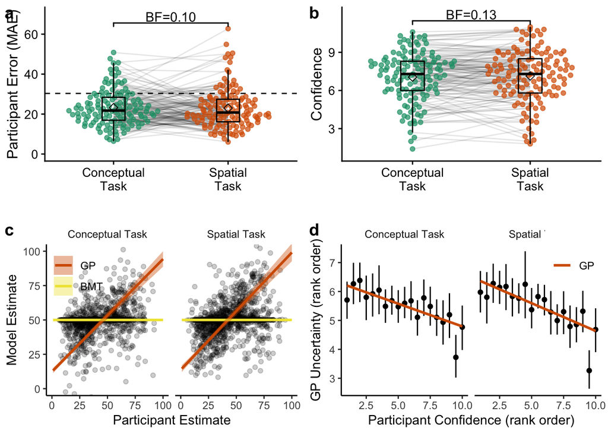

```r
p <- cowplot::plot_grid(p1,p2, p4,p5, ncol=2, labels = 'auto')
p
```

```r
ggsave('../plots/BonusRound.pdf',p, width = 10, height = 6, unit='in', useDingbats=F)
```